# R Notebook

```r
require(tidymodels)
require(tidyverse)
```

```r
library(tidyverse)
#install.packages("hablar")
#library(hablar)
#install.packages("skimr")
#library(skimr)
#require(tidyverse)
#library(tidyverse)
#library(gapminder)#
#install.packages("hablar")
#library(hablar)
#library(dplyr)
#remove.packages(c("ggplot2", "data.table"))
#install.packages('Rcpp', dependencies = TRUE)
#install.packages('ggplot2', dependencies = TRUE)
#install.packages('data.table', dependencies = TRUE)
library(ggplot2)
#library(dplyr)
#install.packages("zoo")
library(vip)
#install.packages("writexl")
#library(writexl)
#install.packages("see")
```

## Introduction to tidy models

```r
Bank_churners<-read_csv("C:/Users/Lenovo/Downloads/BankChurners.csv")
glimpse(Bank_churners)
```

```
## Rows: 5,998
## Columns: 21
## $ CLIENTNUM                  <dbl> 768805383, 818770008, 713982108, 769911858,…
## $ Attrition_Flag             <chr> "Existing Customer", "Existing Customer", "…
## $ Customer_Age               <dbl> 45, 49, 51, 40, 40, 44, 51, 32, 37, 48, 42,…
## $ Gender                     <chr> "M", "F", "M", "F", "M", "M", "M", "M", "M"…
## $ Dependent_count            <dbl> 3, 5, 3, 4, 3, 2, 4, 0, 3, 2, 5, 1, 1, 3, 2…
## $ Education_Level            <chr> "High School", "Graduate", "Graduate", "Hig…
## $ Marital_Status             <chr> "Married", "Single", "Married", "Unknown", …
## $ Income_Category            <chr> "$60K - $80K", "Less than $40K", "$80K - $1…
## $ Card_Category              <chr> "Blue", "Blue", "Blue", "Blue", "Blue", "Bl…
## $ Months_on_book             <dbl> 39, 44, 36, 34, 21, 36, 46, 27, 36, 36, 31,…
## $ `Total_Relationship Count` <dbl> 5, 6, 4, 3, 5, 3, 6, 2, 5, 6, 5, 6, 3, 5, 5…
## $ Months_Inactive_12_mon     <dbl> 1, 1, 1, 4, 1, 1, 1, 2, 2, 3, 3, 2, 6, 1, 2…
## $ Contacts_Count_12_mon      <dbl> 3, 2, 0, 1, 0, 2, 3, 2, 0, 3, 2, 3, 0, 3, 2…
## $ Credit_Limit               <dbl> 12691.0, 8256.0, 3418.0, 3313.0, 4716.0, 40…
## $ Total_Revolving_Bal        <dbl> 777, 864, 0, 2517, 0, 1247, 2264, 1396, 251…
## $ Avg_Open_To_Buy            <dbl> 11914.0, 7392.0, 3418.0, 796.0, 4716.0, 276…
## $ Total_Amt_Chng_Q4_Q1       <dbl> 1.335, 1.541, 2.594, 1.405, 2.175, 1.376, 1…
## $ Total_Trans_Amt            <dbl> 1144, 1291, 1887, 1171, 816, 1088, 1330, 15…
## $ Total_Trans_Ct             <dbl> 42, 33, 20, 20, 28, 24, 31, 36, 24, 32, 42,…
## $ Total_Ct_Chng_Q4_Q1        <dbl> 1.625, 3.714, 2.333, 2.333, 2.500, 0.846, 0…
## $ Avg_Utilization_Ratio      <dbl> 0.061, 0.105, 0.000, 0.760, 0.000, 0.311, 0…
```

```r
Bank_churners%>%head()
```

| CLIENTNUM | Attrition_Flag | Customer_Age | Gender | Dependent_count | Education_Level | Marital_Status | Income_Category | Card_Category | Months_on_book | Total_Relationship Count | Months_Inactive_12_mon | Contacts_Count_12_mon | Credit_Limit | Total_Revolving_Bal | Avg_Open_To_Buy | Total_Amt_Chng_Q4_Q1 | Total_Trans_Amt | Total_Trans_Ct | Total_Ct_Chng_Q4_Q1 | Avg_Utilization_Ratio |
| --- | --- | --- | --- | --- | --- | --- | --- | --- | --- | --- | --- | --- | --- | --- | --- | --- | --- | --- | --- | --- |
| 768805383 | Existing Customer | 45 | M | 3 | High School | Married | $60K - $80K | Blue | 39 | 5 | 1 | 3 | 12691 | 777 | 11914 | 1.335 | 1144 | 42 | 1.625 | 0.061 |
| 818770008 | Existing Customer | 49 | F | 5 | Graduate | Single | Less than $40K | Blue | 44 | 6 | 1 | 2 | 8256 | 864 | 7392 | 1.541 | 1291 | 33 | 3.714 | 0.105 |
| 713982108 | Existing Customer | 51 | M | 3 | Graduate | Married | $80K - $120K | Blue | 36 | 4 | 1 | 0 | 3418 | 0 | 3418 | 2.594 | 1887 | 20 | 2.333 | 0.000 |
| 769911858 | Existing Customer | 40 | F | 4 | High School | Unknown | Less than $40K | Blue | 34 | 3 | 4 | 1 | 3313 | 2517 | 796 | 1.405 | 1171 | 20 | 2.333 | 0.760 |
| 709106358 | Existing Customer | 40 | M | 3 | Uneducated | Married | $60K - $80K | Blue | 21 | 5 | 1 | 0 | 4716 | 0 | 4716 | 2.175 | 816 | 28 | 2.500 | 0.000 |
| 713061558 | Existing Customer | 44 | M | 2 | Graduate | Married | $40K - $60K | Blue | 36 | 3 | 1 | 2 | 4010 | 1247 | 2763 | 1.376 | 1088 | 24 | 0.846 | 0.311 |

```r
summary(Bank_churners)
```

```
##    CLIENTNUM         Attrition_Flag      Customer_Age      Gender
##  Min.   :708083283   Length:5998        Min.   :26.00   Length:5998
##  1st Qu.:713095796   Class :character   1st Qu.:40.00   Class :character
##  Median :718055433   Mode  :character   Median :46.00   Mode  :character
##  Mean   :739795002                      Mean   :46.38
##  3rd Qu.:778343152                      3rd Qu.:52.00
##  Max.   :828343083                      Max.   :73.00
##  Dependent_count Education_Level    Marital_Status     Income_Category
##  Min.   :0.000   Length:5998        Length:5998        Length:5998
##  1st Qu.:1.000   Class :character   Class :character   Class :character
##  Median :2.000   Mode  :character   Mode  :character   Mode  :character
##  Mean   :2.278
##  3rd Qu.:3.000
##  Max.   :5.000
##  Card_Category      Months_on_book  Total_Relationship Count
##  Length:5998        Min.   :13.00   Min.   :1.00
##  Class :character   1st Qu.:31.00   1st Qu.:3.00
##  Mode  :character   Median :36.00   Median :4.00
##                     Mean   :35.98   Mean   :4.31
##                     3rd Qu.:41.00   3rd Qu.:5.00
##                     Max.   :56.00   Max.   :6.00
##  Months_Inactive_12_mon Contacts_Count_12_mon  Credit_Limit
##  Min.   :0.000          Min.   :0.000         Min.   : 1438
##  1st Qu.:2.000          1st Qu.:2.000         1st Qu.: 2644
##  Median :2.000          Median :3.000         Median : 5013
##  Mean   :2.299          Mean   :2.608         Mean   : 8714
##  3rd Qu.:3.000          3rd Qu.:3.000         3rd Qu.:11335
##  Max.   :6.000          Max.   :6.000         Max.   :34516
##  Total_Revolving_Bal Avg_Open_To_Buy Total_Amt_Chng_Q4_Q1 Total_Trans_Amt
##  Min.   :   0.0      Min.   :    3   Min.   :0.0000       Min.   : 510
##  1st Qu.: 580.5      1st Qu.: 1368   1st Qu.:0.6130       1st Qu.:1711
##  Median :1300.5      Median : 3782   Median :0.7380       Median :2566
##  Mean   :1183.5      Mean   : 7530   Mean   :0.7736       Mean   :2816
##  3rd Qu.:1787.8      3rd Qu.:10081   3rd Qu.:0.8860       3rd Qu.:3989
##  Max.   :2517.0      Max.   :34516   Max.   :3.3970       Max.   :5783
##  Total_Trans_Ct   Total_Ct_Chng_Q4_Q1 Avg_Utilization_Ratio
##  Min.   : 10.00   Min.   :0.0000      Min.   :0.000
##  1st Qu.: 38.00   1st Qu.:0.5470      1st Qu.:0.035
##  Median : 56.00   Median :0.6820      Median :0.178
##  Mean   : 54.79   Mean   :0.7065      Mean   :0.276
##  3rd Qu.: 71.00   3rd Qu.:0.8210      3rd Qu.:0.496
##  Max.   :103.00   Max.   :3.7140      Max.   :0.999
```

```r
#skim(Bank_churners)
```

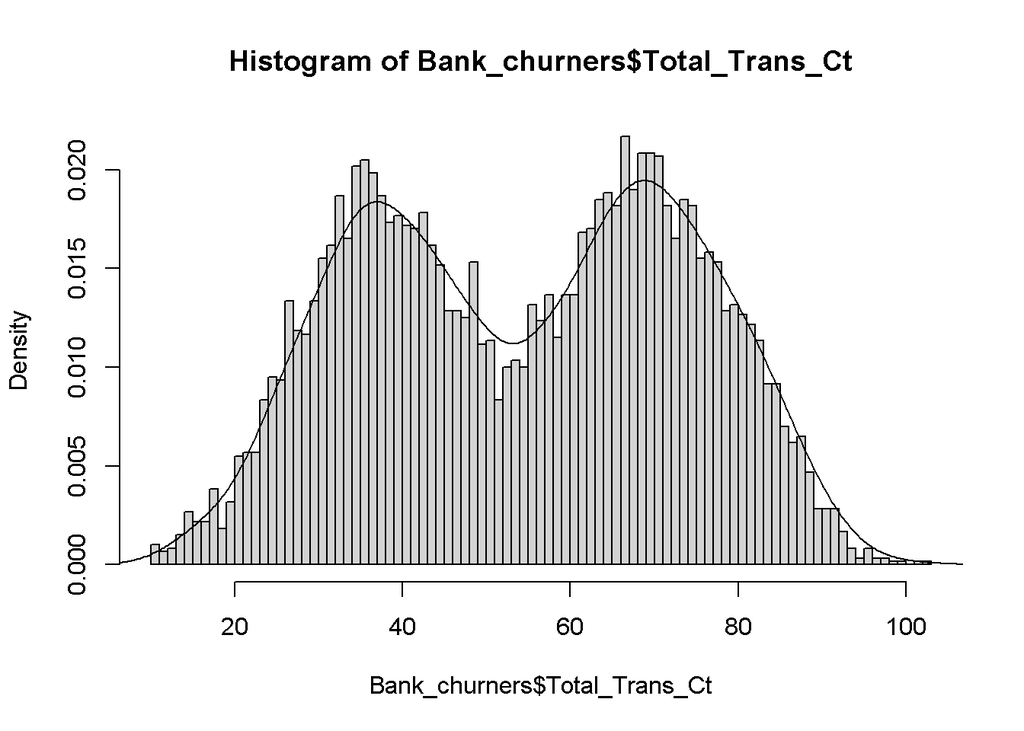

```r
hist(Bank_churners$Total_Trans_Ct,prob=TRUE,breaks=100)
lines(density(Bank_churners$Total_Trans_Ct))
```

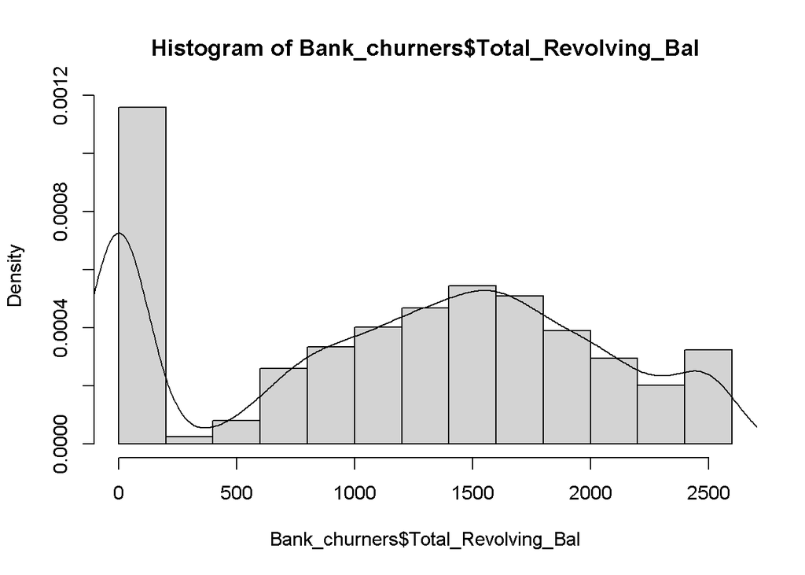

```r
hist(Bank_churners$Total_Revolving_Bal,prob=TRUE,breaks=9)
lines(density(Bank_churners$Total_Revolving_Bal))
```

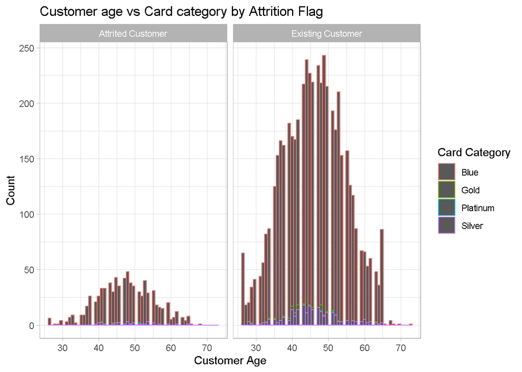

```r
ggplot(data = Bank_churners,
       mapping = aes(x = Customer_Age,color = Card_Category)) +geom_histogram(binwidth = 0.8) +facet_wrap(~ Card_Category) +labs(title =
"Customer age vs Card category by Attrition Flag",x = "Customer Age",y = "Count") +
  scale_color_discrete(name = "Card Category") +theme_light() +facet_wrap(~ Card_Category) +facet_grid(. ~ Attrition_Flag)
```

```r
Bank_churners$Attrition_Flag <- as.numeric(factor(Bank_churners$Attrition_Flag))

set.seed(123)

# Create a split object
Bankchurners_split <- initial_split(Bank_churners, prop = 0.90,
                                   strata = Attrition_Flag)

# Build training data set
Bankchurners_training <- Bankchurners_split %>%
                        training()

# Build testing data set
Bankchurners_test <- Bankchurners_split %>%
                    testing()
```

```r
lm_model <- linear_reg() %>%
            set_engine('lm') %>% # adds lm implementation of linear regression
            set_mode('regression')
```

```r
lm_fit <- lm_model %>%
          fit(Attrition_Flag ~ . , data=Bankchurners_training)
# View lm_fit properties
lm_fit
```

```
## parsnip model object
##
##
## Call:
## stats::lm(formula = Attrition_Flag ~ ., data = data)
##
## Coefficients:
##                   (Intercept)                      CLIENTNUM
##                     9.460e-01                      1.505e-10
##                  Customer_Age                        GenderM
##                    -9.887e-04                      7.362e-02
##               Dependent_count       Education_LevelDoctorate
##                    -1.398e-02                     -5.171e-02
##       Education_LevelGraduate     Education_LevelHigh School
##                    -1.669e-03                     -1.054e-03
##  Education_LevelPost-Graduate      Education_LevelUneducated
##                    -1.643e-02                     -8.740e-03
##        Education_LevelUnknown          Marital_StatusMarried
##                    -1.321e-02                      4.597e-02
##          Marital_StatusSingle          Marital_StatusUnknown
##                    -4.163e-03                      4.899e-03
##    Income_Category$40K - $60K     Income_Category$60K - $80K
##                     5.080e-02                      2.464e-02
##   Income_Category$80K - $120K  Income_CategoryLess than $40K
##                     2.298e-02                      5.213e-02
##        Income_CategoryUnknown              Card_CategoryGold
##                     3.922e-02                     -2.427e-02
##         Card_CategoryPlatinum            Card_CategorySilver
##                    -1.090e-01                     -1.465e-02
##                Months_on_book     `Total_Relationship Count`
##                     3.411e-04                      6.234e-02
##        Months_Inactive_12_mon          Contacts_Count_12_mon
##                    -3.244e-02                     -3.070e-02
##                  Credit_Limit            Total_Revolving_Bal
##                     1.681e-06                      8.390e-05
##               Avg_Open_To_Buy           Total_Amt_Chng_Q4_Q1
##                            NA                      4.902e-02
##               Total_Trans_Amt                 Total_Trans_Ct
##                    -1.742e-05                      7.073e-03
##           Total_Ct_Chng_Q4_Q1          Avg_Utilization_Ratio
##                     2.561e-01                      1.110e-02
```

```r
names(lm_fit)
```

```
## [1] "lvl"     "spec"    "fit"     "preproc" "elapsed"
```

To print a summary of our model, we can extract `fit` from `lm_fit` and pass it to the `summary()` function. We can explore the estimated coefficients, F-statistics, p-values, residual standard error (also known as RMSE) and R2 value.

```r
summary(lm_fit$fit)
```

```
##
## Call:
## stats::lm(formula = Attrition_Flag ~ ., data = data)
##
## Residuals:
##      Min       1Q   Median       3Q      Max
## -1.01659 -0.09171  0.05278  0.17296  0.71362
##
## Coefficients: (1 not defined because of singularities)
##                                 Estimate Std. Error t value Pr(>|t|)
## (Intercept)                    9.460e-01  8.752e-02  10.808  < 2e-16 ***
## CLIENTNUM                      1.505e-10  1.012e-10   1.487  0.13715
## Customer_Age                  -9.887e-04  7.530e-04  -1.313  0.18923
## GenderM                        7.362e-02  1.344e-02   5.479 4.48e-08 ***
## Dependent_count               -1.398e-02  2.918e-03  -4.793 1.69e-06 ***
## Education_LevelDoctorate      -5.171e-02  2.098e-02  -2.464  0.01377 *
## Education_LevelGraduate       -1.669e-03  1.357e-02  -0.123  0.90209
## Education_LevelHigh School    -1.054e-03  1.445e-02  -0.073  0.94183
## Education_LevelPost-Graduate  -1.643e-02  2.051e-02  -0.801  0.42333
## Education_LevelUneducated     -8.740e-03  1.521e-02  -0.575  0.56557
## Education_LevelUnknown        -1.321e-02  1.521e-02  -0.869  0.38515
## Marital_StatusMarried          4.597e-02  1.471e-02   3.124  0.00179 **
## Marital_StatusSingle          -4.163e-03  1.482e-02  -0.281  0.77880
## Marital_StatusUnknown          4.899e-03  1.981e-02   0.247  0.80467
## Income_Category$40K - $60K     5.080e-02  1.891e-02   2.686  0.00725 **
## Income_Category$60K - $80K     2.464e-02  1.703e-02   1.446  0.14814
## Income_Category$80K - $120K    2.298e-02  1.619e-02   1.419  0.15599
## Income_CategoryLess than $40K  5.213e-02  2.082e-02   2.503  0.01234 *
## Income_CategoryUnknown         3.922e-02  2.208e-02   1.776  0.07581 .
## Card_CategoryGold             -2.427e-02  5.213e-02  -0.466  0.64149
## Card_CategoryPlatinum         -1.090e-01  1.926e-01  -0.566  0.57142
## Card_CategorySilver           -1.465e-02  2.046e-02  -0.716  0.47383
## Months_on_book                 3.411e-04  7.605e-04   0.449  0.65375
## `Total_Relationship Count`     6.234e-02  2.968e-03  21.002  < 2e-16 ***
## Months_Inactive_12_mon        -3.244e-02  3.734e-03  -8.686  < 2e-16 ***
## Contacts_Count_12_mon         -3.070e-02  3.250e-03  -9.446  < 2e-16 ***
## Credit_Limit                   1.681e-06  6.890e-07   2.440  0.01474 *
## Total_Revolving_Bal            8.390e-05  6.811e-06  12.318  < 2e-16 ***
## Avg_Open_To_Buy                       NA         NA      NA       NA
## Total_Amt_Chng_Q4_Q1           4.902e-02  1.624e-02   3.018  0.00256 **
## Total_Trans_Amt               -1.742e-05  6.595e-06  -2.642  0.00826 **
## Total_Trans_Ct                 7.073e-03  4.221e-04  16.756  < 2e-16 ***
## Total_Ct_Chng_Q4_Q1            2.561e-01  1.512e-02  16.935  < 2e-16 ***
## Avg_Utilization_Ratio          1.110e-02  2.319e-02   0.479  0.63220
## ---
## Signif. codes:  0 '***' 0.001 '**' 0.01 '*' 0.05 '.' 0.1 ' ' 1
##
## Residual standard error: 0.2709 on 5364 degrees of freedom
## Multiple R-squared:  0.3594, Adjusted R-squared:  0.3556
## F-statistic: 94.06 on 32 and 5364 DF,  p-value: < 2.2e-16
```

We can use the `plot()` function to obtain diagnostic plots for our trained regression model. Again, we must first extract the `fit` object from `lm_fit` and then pass it into `plot()`. These plots provide a check for the main assumptions of the linear regression model.

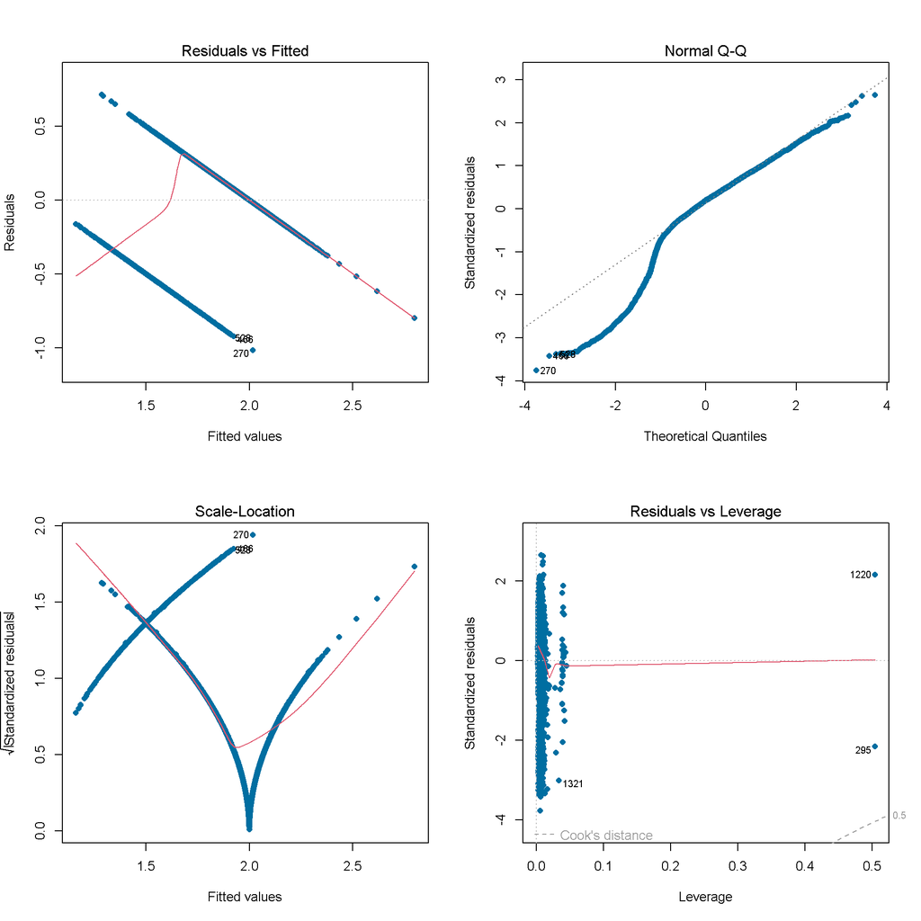

```r
par(mfrow=c(2,2)) # plot all 4 plots in one

plot(lm_fit$fit,
     pch = 16,    # optional parameters to make points blue
     col = '#006EA1')
```

### Tidy Training Results

To obtain the detailed results from our trained linear regression model in a data frame, we can use the `tidy()` and `glance()` functions directly on our trained `parsnip` model, `lm_fit`.

The `glance()` function will return performance metrics obtained on the training data such as the R2 value (`r.squared`) and the RMSE (`sigma`).

```r
# Data frame of estimated coefficients
tidy(lm_fit)
```

| term | estimate | std.error | statistic | p.value |
| --- | --- | --- | --- | --- |
| (Intercept) | 9.459659e-01 | 8.752436e-02 | 10.80802955 | 5.966706e-27 |
| CLIENTNUM | 1.504822e-10 | 1.012191e-10 | 1.48669803 | 1.371534e-01 |
| Customer_Age | -9.886790e-04 | 7.529707e-04 | -1.31303771 | 1.892264e-01 |
| GenderM | 7.361955e-02 | 1.343783e-02 | 5.47853115 | 4.484244e-08 |
| Dependent_count | -1.398243e-02 | 2.917523e-03 | -4.79256889 | 1.691013e-06 |
| Education_LevelDoctorate | -5.170574e-02 | 2.098340e-02 | -2.46412520 | 1.376595e-02 |
| Education_LevelGraduate | -1.669494e-03 | 1.357014e-02 | -0.12302704 | 9.020903e-01 |
| Education_LevelHigh School | -1.054259e-03 | 1.444719e-02 | -0.07297328 | 9.418301e-01 |
| Education_LevelPost-Graduate | -1.642664e-02 | 2.051481e-02 | -0.80072097 | 4.233287e-01 |
| Education_LevelUneducated | -8.739572e-03 | 1.520931e-02 | -0.57461986 | 5.655725e-01 |

[output cut: 24 more lines]

```r
# Performance metrics on training data
glance(lm_fit)
```

| r.squared | adj.r.squared | sigma | statistic | p.value | df | logLik | AIC | BIC | deviance | df.residual | nobs |
| --- | --- | --- | --- | --- | --- | --- | --- | --- | --- | --- | --- |
| 0.3594454 | 0.3556241 | 0.2708654 | 94.0623 | 0 | 32 | -592.2603 | 1252.521 | 1476.703 | 393.5464 | 5364 | 5397 |

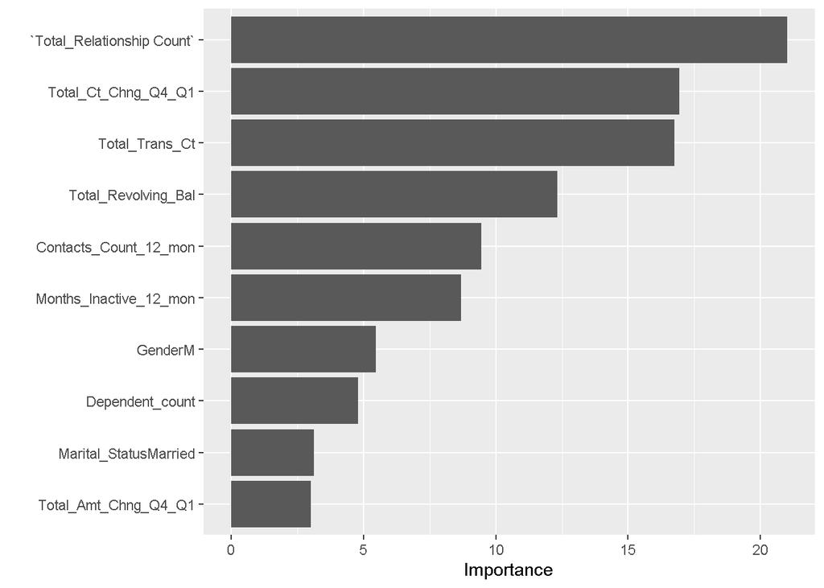

```r
vip(lm_fit)
```

```r
predict(lm_fit, new_data = Bank_churners)
```

| .pred |
| --- |
| 2.164832 |
| 2.617579 |
| 2.170179 |
| 2.073145 |
| 2.331788 |
| 1.805726 |
| 2.035363 |
| 1.817894 |
| 2.182300 |
| 1.930230 |

[output cut: 5988 more lines]

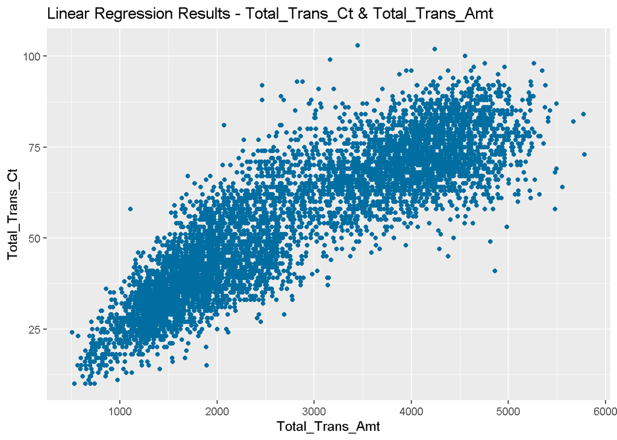

```r
ggplot(data = Bank_churners,
       mapping = aes(x = Total_Trans_Amt, y = Total_Trans_Ct)) +
  geom_point(color = '#006EA1') +
  geom_abline(intercept = 0, slope = 1, color = 'orange') +
  labs(title = 'Linear Regression Results - Total_Trans_Ct & Total_Trans_Amt',
       x = 'Total_Trans_Amt',
       y = 'Total_Trans_Ct')
```